# Prediction of 16srRNA gene copy number

Michela Dell’Alma

2025-01-15

# Aim of the project

The aim of the project is the prediction of 16s rRNA gene copy number for a given genome; the genomes that we are looking at belong to the Alphaproteobacteria.

The approach used for the project is based on the use of Phylogenetic Comparative Methods.

## Introduction and downloading of the genomes

The Alphaproteobacteria is one of the largest group within bacteria, it comprises some of the most environmentally abundant and metabolically diverse organisms on earth. Alphaproteobacteria is of central importance for agricultural (e.g Rhizobia) and medical (e.g. Rickettsia) applications.

In the original table we had a very high amount of Alphaproteobacteria species (alpha_proteobacteria_genomes640.xlsx), we decide to restrict the analysis to a smaller representative group of Alphaproteobacteria, in particular in a paper in which was reconstructed the phylogenetics tree of Alphaproteobacteria [1], have been selected 64 Alphaproteobacterial genomes used also in a previous study, based on two principles:

1. All of the 12 and 9 genomes from Rickettsiales and Holosporales were kept
2. 43 genomes covering all major clades were selected to represent the diversity of Alphaproteobacteria

We decided to restrict the analysis to only this subset of Alphaproteobacteria because of high requirements in terms of memory, computational work and time.

```r
library("readxl")  # read excel table
library("stringr")  # character manipulation
library("dplyr")  # data manipulation
library("writexl") # write excel table
library("lmtest") # perform model evaluation (likelihood-ratio test)
library("picante") # usage of phyestimate function
library("corHMM") # use the corHMM function, used to predict traits for a give genome in the phylogenetic tree
```

Retrieval of a subset of accession numbers associated with organism names

```r
acc_num_paper <- read.table("/Users/micheladellalma/Desktop/PROJECT/2nd_analysis/1_Download_genomes/paper_accession_numbers.txt") # accession numbers present in the paper
colnames(acc_num_paper) <- "Assembly_Accession"
dim(acc_num_paper)
```

```
## [1] 64  1
```

```r
tot_table <- read_excel("/Users/micheladellalma/Desktop/PROJECT/2nd_analysis/1_Download_genomes/alpha_proteobacteria_genomes640.xlsx") # table containing all the alpha-proteobacteria species from our excel file
head(tot_table)
```

```
## # A tibble: 6 × 14
##   Assembly_Accession `Assembly Name` `Organism Name`      Organism Infraspecif…¹
##   <chr>              <chr>           <chr>                <lgl>
## 1 GCA_000022005.1    ASM2200v1       Caulobacter vibrioi… NA
## 2 GCF_000022005.1    ASM2200v1       Caulobacter vibrioi… NA
## 3 GCA_000007125.1    ASM712v1        Brucella melitensis… NA
## 4 GCF_000007125.1    ASM712v1        Brucella melitensis… NA
## 5 GCA_000007505.1    ASM750v1        Brucella suis 1330   NA
## 6 GCF_000007505.1    ASM750v1        Brucella suis 1330   NA
## # ℹ abbreviated name: ¹`Organism Infraspecific Names Breed`
## # ℹ 10 more variables: `Organism Infraspecific Names Strain` <chr>,
## #   `Organism Infraspecific Names Cultivar` <lgl>,
## #   `Organism Infraspecific Names Ecotype` <lgl>,
## #   `Organism Infraspecific Names Isolate` <chr>,
## #   `Organism Infraspecific Names Sex` <lgl>, `Annotation Name` <chr>,
## #   `Assembly Stats Total Sequence Length` <dbl>, `Assembly Level` <chr>, …
```

```r
tot_table_new <- tot_table[,c(1,3)] # take columns 1 and 3 ("Assembly Accession" and "Organism Name" columns)
head(tot_table_new)
```

```
## # A tibble: 6 × 2
##   Assembly_Accession `Organism Name`
##   <chr>              <chr>
## 1 GCA_000022005.1    Caulobacter vibrioides NA1000
## 2 GCF_000022005.1    Caulobacter vibrioides NA1000
## 3 GCA_000007125.1    Brucella melitensis bv. 1 str. 16M
## 4 GCF_000007125.1    Brucella melitensis bv. 1 str. 16M
## 5 GCA_000007505.1    Brucella suis 1330
## 6 GCF_000007505.1    Brucella suis 1330
```

```r
tab_accnum_names <- inner_join(acc_num_paper, tot_table_new,
           by = c("Assembly_Accession")) # join the two tables on the accession number in common, in order to have a table containing accession number of our interest (those present in the paper) and organism name
dim(tab_accnum_names) # 60 rows
```

```
## [1] 60  2
```

```r
head(tab_accnum_names)
```

```
##   Assembly_Accession                         Organism Name
## 1    GCA_000701585.1      Acidiphilium angustum ATCC 35903
## 2    GCA_001295935.1          alpha proteobacterium AAP81b
## 3    GCA_000710935.1             alpha proteobacterium Q-1
## 4    GCA_000469155.1   Candidatus Micropelagos thuwalensis
## 5    GCA_000513055.1 alpha proteobacterium SCGC AAA288-N07
## 6    GCA_000299095.1           alpha proteobacterium HIMB5
```

Modification and Renaming of the ‘Organism Name’ column, creation of a third column “names” containing AssemblyAccession_OrganismName, in order to have the right names on the tips of the phylogenetic tree

```r
# change the 2nd column so that it only contains the first two words (genus and species, separated by an underscore)
# because the other informations are not useful
tab_accnum_names$`Organism Name` <- stringr::word(tab_accnum_names$`Organism Name`, 1, 2, sep=" ")
# remove any cases of new line characters
tab_accnum_names$`Organism Name` <- str_replace_all(tab_accnum_names$`Organism Name`, "[\r\n]" , "")
# add an underscore between the genus and species name
tab_accnum_names$`Organism Name` = gsub(" ", "_", tab_accnum_names$`Organism Name`)
head(tab_accnum_names)
```

```
##   Assembly_Accession           Organism Name
## 1    GCA_000701585.1   Acidiphilium_angustum
## 2    GCA_001295935.1   alpha_proteobacterium
## 3    GCA_000710935.1   alpha_proteobacterium
## 4    GCA_000469155.1 Candidatus_Micropelagos
## 5    GCA_000513055.1   alpha_proteobacterium
## 6    GCA_000299095.1   alpha_proteobacterium
```

```r
# creation of a third column that contains the names of our interest (i.e assemblyaccession_organismname)
tab_accnum_names$names <- paste(tab_accnum_names$Assembly_Accession, tab_accnum_names$`Organism Name`)
tab_accnum_names$names <- gsub(" ", "_", tab_accnum_names$name)
head(tab_accnum_names)
```

```
##   Assembly_Accession           Organism Name
## 1    GCA_000701585.1   Acidiphilium_angustum
## 2    GCA_001295935.1   alpha_proteobacterium
## 3    GCA_000710935.1   alpha_proteobacterium
## 4    GCA_000469155.1 Candidatus_Micropelagos
## 5    GCA_000513055.1   alpha_proteobacterium
## 6    GCA_000299095.1   alpha_proteobacterium
##                                     names
## 1   GCA_000701585.1_Acidiphilium_angustum
## 2   GCA_001295935.1_alpha_proteobacterium
## 3   GCA_000710935.1_alpha_proteobacterium
## 4 GCA_000469155.1_Candidatus_Micropelagos
## 5   GCA_000513055.1_alpha_proteobacterium
## 6   GCA_000299095.1_alpha_proteobacterium
```

Creation of a file containing the accession numbers to download

```r
setwd("/Users/micheladellalma/Desktop/PROJECT/2nd_analysis/1_Download_genomes")
getwd()
```

```
## [1] "/Users/micheladellalma/Desktop/PROJECT/2nd_analysis/1_Download_genomes"
```

```r
df_acc_num <- as.data.frame(tab_accnum_names$Assembly_Accession)
colnames(df_acc_num) <- "Assembly Accession"
write.table(df_acc_num, "acc_num_phylo_tree.txt", quote=FALSE, col.names = FALSE, row.names=FALSE)
```

Download accession numbers’ genomes from ncbi using the command in the script (1_Download.sh). This command download three types of files: gbff, gff3, genomes. The gbff was downloaded in order to extract the number of copies of 16s rRNA, but since this file has no information of number of copies for a significant number of accession numbers, we decide to use another approach.

In particular a tool called barrnap that starting from the gff3 file is able to extract all the 16s rRNA copies (2_Barrnap.sh) for each genome.

## Recovering of 16s rRNA sequences and change of FASTA header names

We move all the fasta files containing the 16s rRNA copies to a folder named 16s_sequences (3_Move16s_seqs.sh).

We change all the fasta header with the accession number and organisms’ informations, this is important to do in order to have the right names in the phylogenetic tree tips

```r
library(phylotools)
setwd("/Users/micheladellalma/Desktop/PROJECT/2nd_analysis/2_Extract_16s_sequences/16s_sequences")
getwd()
```

```
## [1] "/Users/micheladellalma/Desktop/PROJECT/2nd_analysis/2_Extract_16s_sequences/16s_sequences"
```

```r
dir <- "/Users/micheladellalma/Desktop/PROJECT/2nd_analysis/2_Extract_16s_sequences/16s_sequences"
files <- list.files(dir) # get a list of all files .fasta in the name in your directory

# creation of an empty table with two columns
tab_accnum_fasta <- data.frame(matrix(ncol = 2))
colnames(tab_accnum_fasta) <- c("Assembly_Accession", "FASTA_header")

num = 0
for (file in files) {
    name_ext <- basename(file) # path dir without the extension
    name <- tools::file_path_sans_ext(name_ext) # put in the table the accession number without the path of the directory
    header_fasta <- ape::read.FASTA(file) # take the header of the fasta file
    name_seq <- names(header_fasta) # and put it into a variable
    df <- data.frame("Assembly_Accession" = name, "FASTA_header" = name_seq) # creation of a table in which for each fasta header there is the correspondent accession number
    tab_accnum_fasta <- rbind(df, tab_accnum_fasta)
}
head(tab_accnum_fasta)
```

```
##   Assembly_Accession                              FASTA_header
## 1    GCA_004210305.1 16S_rRNA::SCFB01000004.1:110815-112313(-)
## 2    GCA_004210305.1 23S_rRNA::SCFB01000004.1:107506-110260(-)
## 3    GCA_004210305.1  5S_rRNA::SCFB01000004.1:107281-107389(-)
## 4    GCA_004210275.1     16S_rRNA::SCFA01000050.1:1680-3174(+)
## 5    GCA_004210275.1   23S_rRNA::SCFA01000073.1:27225-29988(-)
## 6    GCA_004210275.1    5S_rRNA::SCFA01000073.1:27014-27124(-)
```

```r
# delete last row of the dataframe, that is empty
tab_accnum_fasta <- tab_accnum_fasta[rowSums(is.na(tab_accnum_fasta)) != ncol(tab_accnum_fasta), ]

tab_accnum_fasta$Assembly_Accession <- sub("\\..*", "", tab_accnum_fasta$Assembly_Accession) # delete the numbers of the accession name after the point
tab_accnum_names$Assembly_Accession <- sub("\\..*", "", tab_accnum_names$Assembly_Accession) # delete the numbers of the accession name after the point
```

Join the two tables tab_accnum_fasta and tab_accnum_names on assembly accession number to have for each accnum_orgname, the correspondent fasta header

```r
final_tab <- merge(tab_accnum_names, tab_accnum_fasta, by="Assembly_Accession")
head(final_tab)
```

```
##   Assembly_Accession           Organism Name
## 1      GCA_000008045        Rickettsia_typhi
## 2      GCA_000008045        Rickettsia_typhi
## 3      GCA_000008045        Rickettsia_typhi
## 4      GCA_000012345 Candidatus_Pelagibacter
## 5      GCA_000012345 Candidatus_Pelagibacter
## 6      GCA_000012345 Candidatus_Pelagibacter
##                                     names                          FASTA_header
## 1        GCA_000008045.1_Rickettsia_typhi 16S_rRNA::AE017197.1:779669-781163(-)
## 2        GCA_000008045.1_Rickettsia_typhi 23S_rRNA::AE017197.1:256231-258984(+)
## 3        GCA_000008045.1_Rickettsia_typhi  5S_rRNA::AE017197.1:259216-259326(+)
## 4 GCA_000012345.1_Candidatus_Pelagibacter  5S_rRNA::CP000084.1:564533-564643(+)
## 5 GCA_000012345.1_Candidatus_Pelagibacter 16S_rRNA::CP000084.1:511361-512831(+)
## 6 GCA_000012345.1_Candidatus_Pelagibacter 23S_rRNA::CP000084.1:513243-515993(+)
```

```r
ncol(final_tab)
```

```
## [1] 4
```

Creation of a table in which there are fasta headers and the correspondent new name that we would like to give (accnum_orgname).

The creation of this table is useful because it is required to the rename.fasta function that we are going to use next.

```r
tab_names_header <- final_tab[,c(3,4)]
head(tab_names_header,7)
```

```
##                                     names
## 1        GCA_000008045.1_Rickettsia_typhi
## 2        GCA_000008045.1_Rickettsia_typhi
## 3        GCA_000008045.1_Rickettsia_typhi
## 4 GCA_000012345.1_Candidatus_Pelagibacter
## 5 GCA_000012345.1_Candidatus_Pelagibacter
## 6 GCA_000012345.1_Candidatus_Pelagibacter
## 7         GCA_000012565.1_Ehrlichia_canis
##                              FASTA_header
## 1   16S_rRNA::AE017197.1:779669-781163(-)
## 2   23S_rRNA::AE017197.1:256231-258984(+)
## 3    5S_rRNA::AE017197.1:259216-259326(+)
## 4    5S_rRNA::CP000084.1:564533-564643(+)
## 5   16S_rRNA::CP000084.1:511361-512831(+)
## 6   23S_rRNA::CP000084.1:513243-515993(+)
## 7 23S_rRNA::CP000107.1:1098991-1101775(-)
```

Modification of the table: assign a unique id to the names that are duplicates (multiple copies of 16s rRNA for the same name acc_num_organism).

```r
tab_names_header <- tab_names_header %>%
  group_by(names) %>%
  mutate(Name_ID = paste(names, row_number(), sep = "_")) %>%
  ungroup()
colnames(tab_names_header)
```

```
## [1] "names"        "FASTA_header" "Name_ID"
```

```r
head(tab_names_header)
```

```
## # A tibble: 6 × 3
##   names                                   FASTA_header                   Name_ID
##   <chr>                                   <chr>                          <chr>
## 1 GCA_000008045.1_Rickettsia_typhi        16S_rRNA::AE017197.1:779669-7… GCA_00…
## 2 GCA_000008045.1_Rickettsia_typhi        23S_rRNA::AE017197.1:256231-2… GCA_00…
## 3 GCA_000008045.1_Rickettsia_typhi        5S_rRNA::AE017197.1:259216-25… GCA_00…
## 4 GCA_000012345.1_Candidatus_Pelagibacter 5S_rRNA::CP000084.1:564533-56… GCA_00…
## 5 GCA_000012345.1_Candidatus_Pelagibacter 16S_rRNA::CP000084.1:511361-5… GCA_00…
## 6 GCA_000012345.1_Candidatus_Pelagibacter 23S_rRNA::CP000084.1:513243-5… GCA_00…
```

Take only the columns of our interest (FASTA_header and Name_ID)

```r
tab_names_header <- tab_names_header[,c(2,3)]
head(tab_names_header)
```

```
## # A tibble: 6 × 2
##   FASTA_header                          Name_ID
##   <chr>                                 <chr>
## 1 16S_rRNA::AE017197.1:779669-781163(-) GCA_000008045.1_Rickettsia_typhi_1
## 2 23S_rRNA::AE017197.1:256231-258984(+) GCA_000008045.1_Rickettsia_typhi_2
## 3 5S_rRNA::AE017197.1:259216-259326(+)  GCA_000008045.1_Rickettsia_typhi_3
## 4 5S_rRNA::CP000084.1:564533-564643(+)  GCA_000012345.1_Candidatus_Pelagibacter…
## 5 16S_rRNA::CP000084.1:511361-512831(+) GCA_000012345.1_Candidatus_Pelagibacter…
## 6 23S_rRNA::CP000084.1:513243-515993(+) GCA_000012345.1_Candidatus_Pelagibacter…
```

After having concatenated all the fasta sequences in a unique file (16s_sequences.fasta), we rename the fasta using the previously created table with names and header of the fasta file

```r
setwd("/Users/micheladellalma/Desktop/PROJECT/2nd_analysis/2_Extract_16s_sequences/")
getwd()
```

```
## [1] "/Users/micheladellalma/Desktop/PROJECT/2nd_analysis/2_Extract_16s_sequences"
```

```r
rename.fasta(infile = "16s_sequences.fasta", tab_names_header, outfile = "renamed_16s_seq_new.fasta")
```

```
## renamed_16s_seq_new.fasta has been saved to  /Users/micheladellalma/Desktop/PROJECT/2nd_analysis/2_Extract_16s_sequences
```

## Creation of the table containing number of 16s rRNA copies for each genome

We used this script (4_Count_16srRNA.sh) in order to have a table containing accession numbers and number of copies of 16s rRNA. The output is called “accnum_count16s.txt”.

We create a final table that contains information on Assembly Accession, count of 16s rRNA, organism names and fasta header and we write it to a final txt file (trait_vs_accnum.txt)

```r
final_tab <- merge(tab_names_header, final_tab, by="FASTA_header") # table with names ID (not duplicates)
final_tab <- final_tab[order(final_tab$`Organism Name`),]
trait_tab <- read.table("/Users/micheladellalma/Desktop/PROJECT/2nd_analysis/3_Extract_num_16s_per_genome/accnum_count16s.txt")
colnames(trait_tab) <- c("Assembly_Accession", "count")
dim(trait_tab)
```

```
## [1] 60  2
```

```r
tot_info_table <- merge(trait_tab, final_tab, by = "Assembly_Accession")
dim(tot_info_table)
```

```
## [1] 299   6
```

```r
setwd("/Users/micheladellalma/Desktop/PROJECT/2nd_analysis/5_Phylogenetic_tree/")
getwd()
```

```
## [1] "/Users/micheladellalma/Desktop/PROJECT/2nd_analysis/5_Phylogenetic_tree"
```

```r
write.table(tot_info_table, "trait_vs_accnum.txt")
head(tot_info_table)
```

```
##   Assembly_Accession count                          FASTA_header
## 1      GCA_000008045     3 16S_rRNA::AE017197.1:779669-781163(-)
## 2      GCA_000008045     3 23S_rRNA::AE017197.1:256231-258984(+)
## 3      GCA_000008045     3  5S_rRNA::AE017197.1:259216-259326(+)
## 4      GCA_000012345     3 23S_rRNA::CP000084.1:513243-515993(+)
## 5      GCA_000012345     3 16S_rRNA::CP000084.1:511361-512831(+)
## 6      GCA_000012345     3  5S_rRNA::CP000084.1:564533-564643(+)
##                                     Name_ID           Organism Name
## 1        GCA_000008045.1_Rickettsia_typhi_1        Rickettsia_typhi
## 2        GCA_000008045.1_Rickettsia_typhi_2        Rickettsia_typhi
## 3        GCA_000008045.1_Rickettsia_typhi_3        Rickettsia_typhi
## 4 GCA_000012345.1_Candidatus_Pelagibacter_3 Candidatus_Pelagibacter
## 5 GCA_000012345.1_Candidatus_Pelagibacter_2 Candidatus_Pelagibacter
## 6 GCA_000012345.1_Candidatus_Pelagibacter_1 Candidatus_Pelagibacter
##                                     names
## 1        GCA_000008045.1_Rickettsia_typhi
## 2        GCA_000008045.1_Rickettsia_typhi
## 3        GCA_000008045.1_Rickettsia_typhi
## 4 GCA_000012345.1_Candidatus_Pelagibacter
## 5 GCA_000012345.1_Candidatus_Pelagibacter
## 6 GCA_000012345.1_Candidatus_Pelagibacter
```

## Analysis of the phylogenetic tree

All copies of 16s rRNA sequences for each organism have been taken into account in order to build a phylogenetic tree in the MEGA software.

The algorithm used for sequence alignment was MUSCLE, because MUSCLE has a significant speed advantage over the others MSA algorithm [2], like clustalw that we tried to use it but it takes very much time.

The algorithm used for phylogenetic tree building was the neighbor-joining one, because it is faster respect to other methods.

One error that we encountered during the usage of the neighbor-joining algorithm in the building of the phylogenetic tree is “MEGA was unable to calculate the distance between one and several of the sequence pairs in the alignment”, for this reason we identify such offending pairs and remove it from the phylogenetic tree (we identify them because the error also point out the accession numbers to delete)

Loading phylogenetic tree, computed by MEGA software

```r
library(phytools)
setwd("/Users/micheladellalma/Desktop/PROJECT/2nd_analysis/5_Phylogenetic_tree")
getwd()
```

```
## [1] "/Users/micheladellalma/Desktop/PROJECT/2nd_analysis/5_Phylogenetic_tree"
```

```r
phylo_tree <- read.newick("Newick Export.nwk")
str(phylo_tree) # see the components present in the tree object, in particular it is a list composed by 5 elements
```

```
## List of 5
##  $ edge       : num [1:591, 1:2] 298 299 300 301 302 303 304 305 306 307 ...
##  $ Nnode      : int 295
##  $ tip.label  : chr [1:297] "GCA_000022685.1_Methylorubrum_extorquens_9" "GCA_000022685.1_Methylorubrum_extorquens_4" "GCA_000022685.1_Methylorubrum_extorquens_8" "GCA_000022685.1_Methylorubrum_extorquens_2" ...
##  $ edge.length: num [1:591] 0.0382 0.031 0.0143 0.1272 0.0575 ...
##  $ node.label : NULL
##  - attr(*, "class")= chr "phylo"
##  - attr(*, "order")= chr "cladewise"
```

[output not shown]

[output not shown]

Drop labels from the tot_info_tab table, these accession numbers correspond to the ones we have deleted in the MEGA phylogenetic tree because of the error on pairwise alignment

```r
tab_trait_treename <- as.data.frame(tab_trait_treename)
labels_data <- c("GCA_000300275.1_Thalassospira_profundimaris_1", "GCA_000375545.1_Kordiimonas_gwangyangensis_1")
tab_trait_treename <- tab_trait_treename %>%
  filter(!(row.names(tab_trait_treename) %in% labels_data))
```

Check dimensions

```r
dim(tab_trait_treename)
```

```
## [1] 297   2
```

Re-checking names

```r
name.check(phylo_tree,tab_trait_treename)
```

```
## [1] "OK"
```

Plot phylogenetic tree

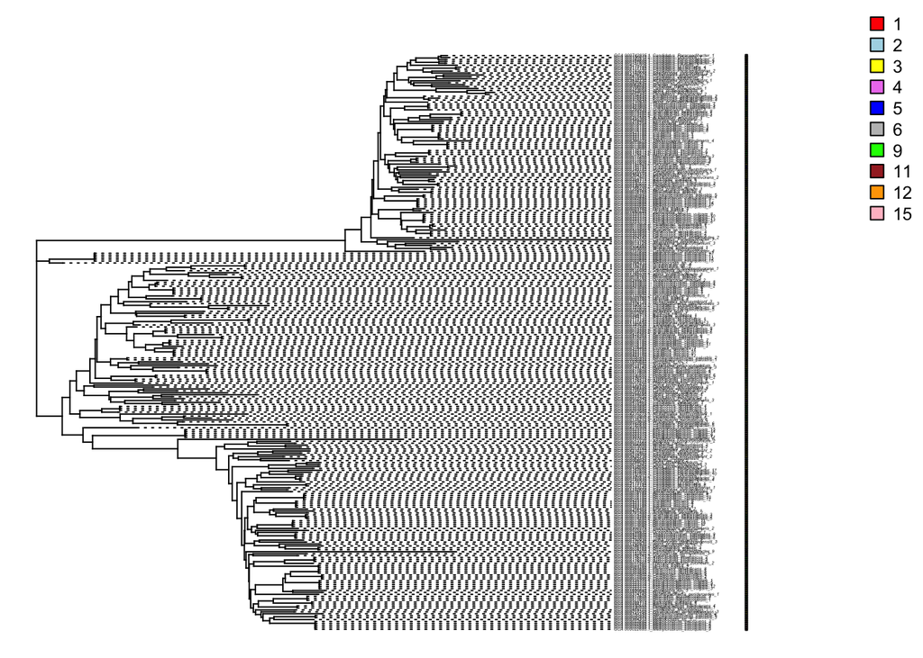

```r
## extract number of copies as a vector
num.copies <- setNames(tab_trait_treename[,2], rownames(tab_trait_treename))
## set colors for plotting
cols <- setNames(c("red","lightblue", "yellow","violet","blue","grey","green","brown","orange","pink"), levels(as.factor(num.copies)))
## plot the tree & data
plotTree.datamatrix(phylo_tree,as.data.frame(num.copies),
                    colors=list(cols), header=FALSE, fsize=0.2)
## add legend
legend("topright", levels(as.factor(num.copies)),pch=22,
       pt.cex=1.5,pt.bg=cols,bty="n",cex=0.8)
```

## Further steps

1. Find the model that apply to our phylogenetic tree-traits
2. Plot of the tree according to the model

3.a. Prediction of missing traits with phyestimate

3.b. Phyestimate used in the prediction of the number of copies of 16s rRNA for all the group of 16s rRNA sequences in a specific organism

3.c. Phyestimate used in the prediction of the number of copies of 16s rRNA taking into account only one copy of 16s rRNA for each genome/organism

4. Correlation between predicted and effective trait
5. Try to use another approach to estimate the trait, that exploits also the information of the specific model

### 1. Fitting discrete character evolution models and reconstructing evolution models

The dominant model for the evolution of discrete characters on phylogenies is a model that has been named the Mk model [Lewis 2001].

The Mk model is so dominated because it describes a continous-time, discrete k-state Markov process. The Mk process is one in which changes can occur between states at any time, and the rate of change to other states depend only on the current state of the chain and not on any prior state or on how long the chain has been in its current state. The process has no historical “memory”, all that matters is the current state and the rate of change from that state to others [3].

Here we fit three different commonly used discrete Mk models called, in order of complexity:

- ER (Equal Rates) model
- SYM (Symmetric Rates) model
- ARD (All Rates Different) model

```r
fitER <- fitMk(phylo_tree,num.copies,model="ER") # Equal-Rates model fits a single transition rate between all pairs of states for our discrete trait
fitSYM <- fitMk(phylo_tree,num.copies,model="SYM") # Symmetric transition model assumes that the rate of transition from each character state i to each state j is equal
# to the rate of change from state j to state i but each pair of character states can have a different rate
fitARD <- fitMk(phylo_tree,num.copies,model="ARD") # All-Rates-Different model assumes that every type of transition is allowed to occur with a different rate
```

Likelihood-ratio test

```r
## comparing ER & SYM
lrtest(fitER,fitSYM)
```

```
## Likelihood ratio test
##
## Model 1: fitER
## Model 2: fitSYM
##   #Df  LogLik Df  Chisq Pr(>Chisq)
## 1   1 -314.47
## 2  45 -280.58 44 67.777    0.01217 *
## ---
## Signif. codes:  0 '***' 0.001 '**' 0.01 '*' 0.05 '.' 0.1 ' ' 1
```

Here, since P<0.05 (0.01217), we reject the simpler ER model in favor of the SYM model

```r
## comparing ER & ARD
lrtest(fitER,fitARD)
```

```
## Likelihood ratio test
##
## Model 1: fitER
## Model 2: fitARD
##   #Df  LogLik Df  Chisq Pr(>Chisq)
## 1   1 -314.47
## 2  90 -261.03 89 106.88    0.09529 .
## ---
## Signif. codes:  0 '***' 0.001 '**' 0.01 '*' 0.05 '.' 0.1 ' ' 1
```

Here, since P>0.05 (0.09529), we can’t reject the simpler ER model in favor of the ARD model

```r
## comparing SYM & ARD
lrtest(fitSYM,fitARD)
```

```
## Likelihood ratio test
##
## Model 1: fitSYM
## Model 2: fitARD
##   #Df  LogLik Df  Chisq Pr(>Chisq)
## 1  45 -280.58
## 2  90 -261.03 45 39.103      0.719
```

Here, since P>0.05 (0.719), we can’t reject the simpler SYM model in favor of the ARD model.

Now we compare all models to each other, using AIC (Akaike Information Criterion), we’ll sort the models in order of complexity

```r
## extract AIC values for each model
aic <- setNames(c(AIC(fitER), AIC(fitSYM), AIC(fitARD)), c("ER", "SYM", "ARD"))
## print summary vector
print(aic)
```

```
##       ER      SYM      ARD
## 630.9474 651.1702 702.0673
```

We decide to use the ER model that has lower values of AIC, AIC score takes into account the complexity (number of parameters in the model).

We can also compute Akaike weights, that show the weight of evidence in support of each model in our data.

```r
aic.w(aic)
```

```
##         ER        SYM        ARD
## 0.99995939 0.00004061 0.00000000
```

The weight for the ER model is much higher than the rest. The other two models are poorly supported by the data.

Finally, we summarize all the different comparisons in one table

```r
round(data.frame(
  logL=c(logLik(fitER), logLik(fitSYM), logLik(fitARD)),
  AIC=aic,Akaike.w=as.vector(aic.w(aic))),3)
```

```
##         logL     AIC Akaike.w
## ER  -314.474 630.947        1
## SYM -280.585 651.170        0
## ARD -261.034 702.067        0
```

### 2. Plot the tree according to the model

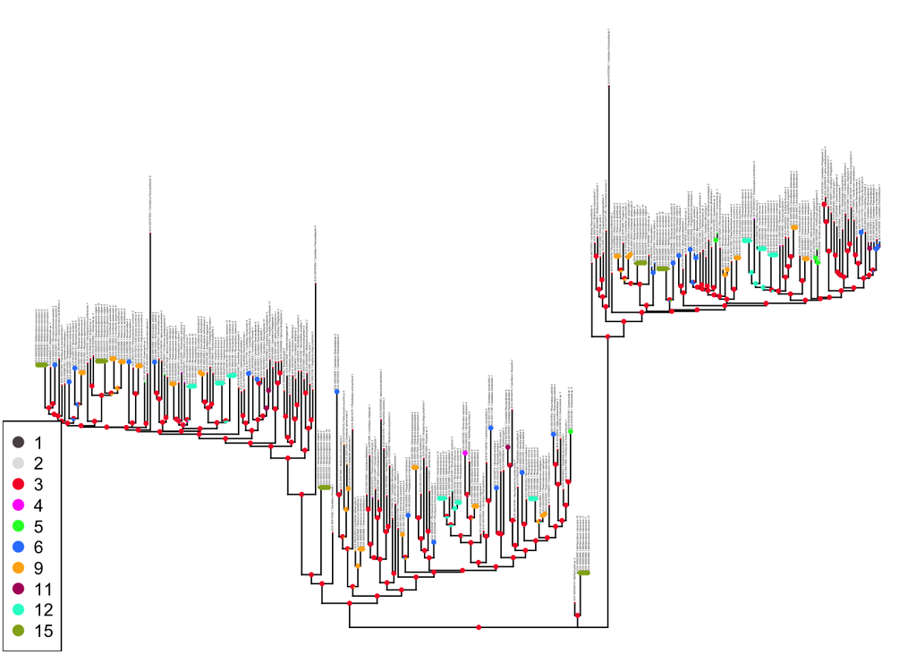

```r
library(magrittr)
fitMk(phylo_tree, num.copies, model="ER", pi="fitzjohn", logscale=TRUE,lik.func="pruning") %>%
  ancr %>%
  plot(args.plotTree=list(direction="upwards"))
```

### 3. a. Prediction of missing traits with phyestimate

Now we take away from the trait data, one accession number at a time and we see if can be predicted with phyestimate function

In the phyestimate function the ML method is used, since as we saw previously the best model to fit our data is the Mk model and this model belongs to the ML method

```r
estimateCUE2 <- data.frame(matrix(ncol=3))
colnames(estimateCUE2) <- c("Taxa", "Trait_predicted", "Trait_real")
for(i in 1:297) {
  num.copies_sub <- num.copies[-i]
  estimater<-phyEstimateDisc(phylo_tree, num.copies_sub, method="ML", best.state = FALSE) # used the Maximum-Likelihood approach for ancestral state reconstruction because is the only one possible for discrete characters estimation
  taxa <- row.names(estimater)
  est <- max.col(estimater)
  true_vl_df <- as.data.frame(num.copies[i])
  colnames(true_vl_df) <- "Num_copies"
  true_vl <- true_vl_df$Num_copies
  estimateCUE2<-rbind(estimateCUE2, c(taxa, est, true_vl))
}
estimateCUE2 <- estimateCUE2[-1,]
# delete first row in the dataframe
```

### 4. a. Correlation between predicted and effective trait

Check correlation between estimated values and real values

```r
estimateCUE2$Trait_real <- as.numeric(as.character(estimateCUE2$Trait_real))# transforming columns into numeric
estimateCUE2$Trait_predicted <- as.numeric(as.character(estimateCUE2$Trait_predicted))
print(cor.test(estimateCUE2$Trait_real, estimateCUE2$Trait_predicted, method="spearman"))
```

```
##
##  Spearman's rank correlation rho
##
## data:  estimateCUE2$Trait_real and estimateCUE2$Trait_predicted
## S = 391566, p-value < 2.2e-16
## alternative hypothesis: true rho is not equal to 0
## sample estimates:
##       rho
## 0.9103208
```

There is a very high correlation between estimated and true value predicted, so the ancestral state reconstruction that exploits the maximum-likelihood method is an optimal approach to predict discrete trait values in a phylogenetic tree.

Maybe the prediction could be even more precise by using the information of the model that best fits the data, that is the Mk model with Equal Rates probabilities.

Although the phyestimate function does a good job in prediction, could be used another function that is called corHMM that could be even more precise, since it takes into account the information of the model that best fits our data (ER)

### 3 b. Phyestimate used in the prediction of the number of copies of 16s rRNA for all the group of 16s rRNA sequences in specific organisms

We use the phyestimate function on 3 organisms and we evaluate the predicted and true value

Candidatus Finniella

```r
library(picante)
estimateCUE2 <- data.frame(matrix(ncol=3))
colnames(estimateCUE2) <- c("Taxa", "Trait_predicted", "Trait_real")
# creation of a list of lists
# in particular the inner lists contain the Accnum_orgname for all the copies of 16s rRNA for a specific organism

num.copies_sub <- num.copies[-c(295,296,297)]
estimater <- phyEstimateDisc(phylo_tree, num.copies_sub, method="ML", best.state = FALSE) # used the Maximum-Likelihood approach for ancestral state reconstruction because is the only one possible for discrete characters estimation
taxa <- row.names(estimater)[1]
est <- mean(max.col(estimater))
true_vl_df <- as.data.frame(num.copies[c(295,296,297)])
colnames(true_vl_df) <- "Num_copies"
true_vl <- mean(true_vl_df$Num_copies)
estimateCUE2<-rbind(estimateCUE2, c(taxa, est, true_vl))
```

Rickettsia typhi

```r
num.copies_sub <- num.copies[-c(1,2,3)]
estimater <- phyEstimateDisc(phylo_tree, num.copies_sub, method="ML", best.state = FALSE) # used the Maximum-Likelihood approach for ancestral state reconstruction because is the only one possible for discrete characters estimation
taxa <- row.names(estimater)[1]
est <- mean(max.col(estimater))
true_vl_df <- as.data.frame(num.copies[c(1,2,3)])
colnames(true_vl_df) <- "Num_copies"
true_vl <- mean(true_vl_df$Num_copies)
estimateCUE2<-rbind(estimateCUE2, c(taxa, est, true_vl))
```

Candidatus Pelagibacter

```r
num.copies_sub <- num.copies[-c(4,5,6)]
estimater <- phyEstimateDisc(phylo_tree, num.copies_sub, method="ML", best.state = FALSE) # used the Maximum-Likelihood approach for ancestral state reconstruction because is the only one possible for discrete characters estimation
taxa <- row.names(estimater)[1]
est <- mean(max.col(estimater))
true_vl_df <- as.data.frame(num.copies[c(4,5,6)])
colnames(true_vl_df) <- "Num_copies"
true_vl <- mean(true_vl_df$Num_copies)
estimateCUE2<-rbind(estimateCUE2, c(taxa, est, true_vl))
estimateCUE2 <- estimateCUE2[-1,]
print(estimateCUE2)
```

```
##                                        Taxa Trait_predicted Trait_real
## 2    GCA_004210305.1_Candidatus_Finniella_3               3          3
## 3        GCA_000008045.1_Rickettsia_typhi_2               3          3
## 4 GCA_000012345.1_Candidatus_Pelagibacter_3               3          3
```

By deleting the informations of the number of copies of the 16s rRNA sequences in the same organism, the prediction seems to be still effective, because predicted and real values are equal

Now we redo all the analysis but with a phylogenetic tree that does not contain all the 16s rRNA copies, instead it contains only one copy of 16s rRNA for each organism

We have already produced the files containing all the 16s rRNA sequences (one copy for each organism)

### 3.c. Phyestimate used in the prediction of the number of copies of 16s rRNA taking into account only one copy of 16s rRNA for each genome/organism

Already created FASTA files containing only one 16s rRNA for each accession number, the files are present in the folder 16s_sequences, and have been retrieved using this script extract1stseq.sh (/Users/micheladellalma/Desktop/PROJECT/3rd_analysis/2_Extract_16s_sequences/extract1stseq.sh)

```r
library(phylotools)
setwd("/Users/micheladellalma/Desktop/PROJECT/3rd_analysis/2_Extract_16s_sequences/16s_sequences")
getwd()
```

```
## [1] "/Users/micheladellalma/Desktop/PROJECT/3rd_analysis/2_Extract_16s_sequences/16s_sequences"
```

```r
dir <- "/Users/micheladellalma/Desktop/PROJECT/3rd_analysis/2_Extract_16s_sequences/16s_sequences"
files <- list.files(dir) # get a list of all files .fasta in the name in your directory

# creation of an empty table with two columns
tab_accnum_fasta <- data.frame(matrix(ncol = 2))
colnames(tab_accnum_fasta) <- c("Assembly_Accession", "FASTA_header")

num = 0
for (file in files) {
    name_ext <- basename(file) # path dir without the extension
    name <- tools::file_path_sans_ext(name_ext) # put in the table the accession number without the path of the directory
    header_fasta <- ape::read.FASTA(file) # take the header of the fasta file
    name_seq <- names(header_fasta) # and put it into a variable
    df <- data.frame("Assembly_Accession" = name, "FASTA_header" = name_seq) # creation of a table in which for each fasta header there is the correspondent accession number
    tab_accnum_fasta <- rbind(df, tab_accnum_fasta)
}
head(tab_accnum_fasta)
```

```
##   Assembly_Accession                              FASTA_header
## 1    GCA_004210305.1 16S_rRNA::SCFB01000004.1:110815-112313(-)
## 2    GCA_004210275.1     16S_rRNA::SCFA01000050.1:1680-3174(+)
## 3    GCA_003932735.1     16S_rRNA::CP033611.1:966065-967561(+)
## 4    GCA_002117145.1   16S_rRNA::CP008743.1:1638359-1639843(+)
## 5    GCA_001650845.1   16S_rRNA::LXYJ01000030.1:27776-29238(-)
## 6    GCA_001295935.1     16S_rRNA::LJHX01000075.1:1803-3286(+)
```

```r
# delete last row of the dataframe, that is empty
tab_accnum_fasta <- tab_accnum_fasta[rowSums(is.na(tab_accnum_fasta)) != ncol(tab_accnum_fasta), ]

tab_accnum_fasta$Assembly_Accession <- sub("\\..*", "", tab_accnum_fasta$Assembly_Accession) # delete the numbers of the accession name after the point
tab_accnum_names$Assembly_Accession <- sub("\\..*", "", tab_accnum_names$Assembly_Accession) # delete the numbers of the accession name after the point
```

[output not shown]

[output not shown]

Creation of a table in which there are fasta headers and the correspondent new name that we would like to give (accnum_orgname).

The creation of this table is useful because it is required to the rename.fasta function that we will use next

```r
tab_names_header <- final_tab[,c(3,4)]
head(tab_names_header,7)
```

```
##                                       names
## 1          GCA_000008045.1_Rickettsia_typhi
## 2   GCA_000012345.1_Candidatus_Pelagibacter
## 3           GCA_000012565.1_Ehrlichia_canis
## 4   GCA_000012905.2_Cereibacter_sphaeroides
## 5     GCA_000013085.1_Rhodospirillum_rubrum
## 6 GCA_000013125.1_Anaplasma_phagocytophilum
## 7    GCA_000013165.1_Neorickettsia_sennetsu
##                              FASTA_header
## 1   16S_rRNA::AE017197.1:779669-781163(-)
## 2   16S_rRNA::CP000084.1:511361-512831(+)
## 3   16S_rRNA::CP000107.1:285936-287439(+)
## 4     16S_rRNA::CP000144.2:33676-35140(+)
## 5   16S_rRNA::CP000230.1:192523-194004(+)
## 6 16S_rRNA::CP000235.1:1057413-1058914(-)
## 7     16S_rRNA::CP000237.1:36271-37764(+)
```

```r
tab_names_header <- tab_names_header[,c(2,1)]
head(tab_names_header)
```

```
##                              FASTA_header
## 1   16S_rRNA::AE017197.1:779669-781163(-)
## 2   16S_rRNA::CP000084.1:511361-512831(+)
## 3   16S_rRNA::CP000107.1:285936-287439(+)
## 4     16S_rRNA::CP000144.2:33676-35140(+)
## 5   16S_rRNA::CP000230.1:192523-194004(+)
## 6 16S_rRNA::CP000235.1:1057413-1058914(-)
##                                       names
## 1          GCA_000008045.1_Rickettsia_typhi
## 2   GCA_000012345.1_Candidatus_Pelagibacter
## 3           GCA_000012565.1_Ehrlichia_canis
## 4   GCA_000012905.2_Cereibacter_sphaeroides
## 5     GCA_000013085.1_Rhodospirillum_rubrum
## 6 GCA_000013125.1_Anaplasma_phagocytophilum
```

After having concatenated all the FASTA sequences in a unique file (16s_sequences.fasta), we rename the FASTA using the previously created table with names and header of the FASTA file

```r
setwd("/Users/micheladellalma/Desktop/PROJECT/3rd_analysis/2_Extract_16s_sequences/")
getwd()
```

```
## [1] "/Users/micheladellalma/Desktop/PROJECT/3rd_analysis/2_Extract_16s_sequences"
```

```r
rename.fasta(infile = "16s_sequences.fasta", tab_names_header, outfile = "renamed_16s_seq_new.fasta")
```

```
## renamed_16s_seq_new.fasta has been saved to  /Users/micheladellalma/Desktop/PROJECT/3rd_analysis/2_Extract_16s_sequences
```

We used this script (4_Count_16srRNA.sh) to have a table containing accession numbers and number of copies of 16s rRNA. The output is called “accnum_count16s.txt”.

We create a final table that contains information on Assembly Accession, count of 16s rRNA, organism names and fasta header and we write it to a final txt file (trait_vs_accnum.txt)

```r
final_tab <- merge(tab_names_header, final_tab, by="FASTA_header") # table with names ID (not duplicates)
final_tab <- final_tab[order(final_tab$`Organism Name`),]
trait_tab <- read.table("/Users/micheladellalma/Desktop/PROJECT/3rd_analysis/3_Extract_num_16s_per_genome/accnum_count16s.txt")
colnames(trait_tab) <- c("Assembly_Accession", "count")
dim(trait_tab)
```

```
## [1] 60  2
```

```r
tot_info_table <- merge(trait_tab, final_tab, by = "Assembly_Accession")
dim(tot_info_table)
```

```
## [1] 60  6
```

```r
setwd("/Users/micheladellalma/Desktop/PROJECT/3rd_analysis/5_Phylogenetic_tree/")
getwd()
```

```
## [1] "/Users/micheladellalma/Desktop/PROJECT/3rd_analysis/5_Phylogenetic_tree"
```

```r
write.table(tot_info_table, "trait_vs_accnum.txt")
head(tot_info_table)
```

```
##   Assembly_Accession count                            FASTA_header
## 1      GCA_000008045     3   16S_rRNA::AE017197.1:779669-781163(-)
## 2      GCA_000012345     3   16S_rRNA::CP000084.1:511361-512831(+)
## 3      GCA_000012565     3   16S_rRNA::CP000107.1:285936-287439(+)
## 4      GCA_000012905     9     16S_rRNA::CP000144.2:33676-35140(+)
## 5      GCA_000013085    12   16S_rRNA::CP000230.1:192523-194004(+)
## 6      GCA_000013125     3 16S_rRNA::CP000235.1:1057413-1058914(-)
##                                     names.x             Organism Name
## 1          GCA_000008045.1_Rickettsia_typhi          Rickettsia_typhi
## 2   GCA_000012345.1_Candidatus_Pelagibacter   Candidatus_Pelagibacter
## 3           GCA_000012565.1_Ehrlichia_canis           Ehrlichia_canis
## 4   GCA_000012905.2_Cereibacter_sphaeroides   Cereibacter_sphaeroides
## 5     GCA_000013085.1_Rhodospirillum_rubrum     Rhodospirillum_rubrum
## 6 GCA_000013125.1_Anaplasma_phagocytophilum Anaplasma_phagocytophilum
##                                     names.y
## 1          GCA_000008045.1_Rickettsia_typhi
## 2   GCA_000012345.1_Candidatus_Pelagibacter
## 3           GCA_000012565.1_Ehrlichia_canis
## 4   GCA_000012905.2_Cereibacter_sphaeroides
## 5     GCA_000013085.1_Rhodospirillum_rubrum
## 6 GCA_000013125.1_Anaplasma_phagocytophilum
```

### Analysis of the phylogenetic tree

```r
library(phytools)
setwd("/Users/micheladellalma/Desktop/PROJECT/3rd_analysis/5_Phylogenetic_tree")
getwd()
```

```
## [1] "/Users/micheladellalma/Desktop/PROJECT/3rd_analysis/5_Phylogenetic_tree"
```

```r
phylo_tree <- read.newick("Newick Export.nwk")
str(phylo_tree) # see the components present in the tree object, in particular it is a list composed by 5 elements
```

```
## List of 5
##  $ edge       : num [1:117, 1:2] 61 62 63 64 65 66 67 68 69 70 ...
##  $ Nnode      : int 58
##  $ tip.label  : chr [1:60] "GCA_000020445.1_Rhodopseudomonas_palustris" "GCA_000022685.1_Methylorubrum_extorquens" "GCA_000304315.1_Methylocystis_sp." "GCA_000374145.1_Neomegalonema_perideroedes" ...
##  $ edge.length: num [1:117] 0.00445 0.00952 0.00239 0.00122 0.00181 ...
##  $ node.label : NULL
##  - attr(*, "class")= chr "phylo"
##  - attr(*, "order")= chr "cladewise"
```

```r
library(geiger)
# take only the names used either in the tree and the counts (trait)
tab_trait_treename <- tot_info_table[,c(4,2)] # take column "count" and "Name_ID"
# put Name_ID as row name
row.names(tab_trait_treename) <- tab_trait_treename$names.x
tab_trait_treename$names.x <- NULL
name.check(phylo_tree, tab_trait_treename) # check that the tree and the trait table contain the same Accnum_organismname
```

```
## [1] "OK"
```

```r
head(tab_trait_treename)
```

```
##                                           count
## GCA_000008045.1_Rickettsia_typhi              3
## GCA_000012345.1_Candidatus_Pelagibacter       3
## GCA_000012565.1_Ehrlichia_canis               3
## GCA_000012905.2_Cereibacter_sphaeroides       9
## GCA_000013085.1_Rhodospirillum_rubrum        12
## GCA_000013125.1_Anaplasma_phagocytophilum     3
```

Plot phylogenetic tree

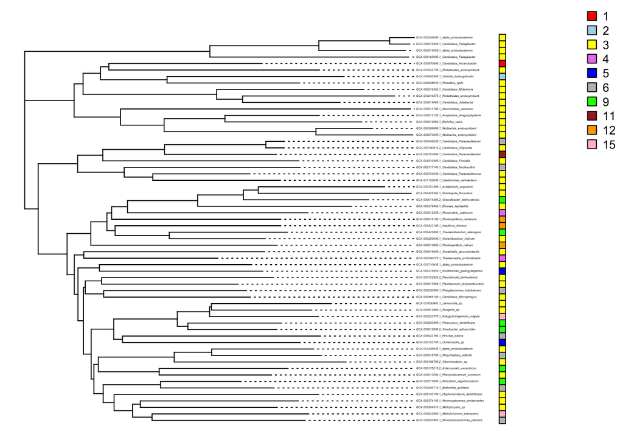

```r
## extract number of copies as a vector
num.copies <- setNames(tab_trait_treename[,1], rownames(tab_trait_treename))
## set colors for plotting
cols <- setNames(c("red","lightblue", "yellow","violet","blue","grey","green","brown","orange","pink"), levels(as.factor(num.copies)))
## plot the tree & data
plotTree.datamatrix(phylo_tree,as.data.frame(num.copies),
                    colors=list(cols), header=FALSE, fsize=0.2)
## add legend
legend("topright", levels(as.factor(num.copies)),pch=22,
       pt.cex=1.5,pt.bg=cols,bty="n",cex=0.8)
```

### 3.c. Prediction of missing traits with phyestimate

Now we take away from the trait data, one accession number at a time and we see if can be predicted with phyestimate function

In the phyestimate function the ML method is used, since as we saw previously the best model to fit our data is the Mk model and this model belongs to the ML method

```r
library(picante)
estimateCUE2 <- data.frame(matrix(ncol=3))
colnames(estimateCUE2) <- c("Taxa", "Trait_predicted", "Trait_real")
for(i in 1:60) {
  num.copies_sub <- num.copies[-i]
  estimater<-phyEstimateDisc(phylo_tree, num.copies_sub, method="ML", best.state = FALSE) # used the Maximum-Likelihood approach for ancestral state reconstruction because is the only one possible for discrete characters estimation
  taxa <- row.names(estimater)
  est <- max.col(estimater)
  true_vl_df <- as.data.frame(num.copies[i])
  colnames(true_vl_df) <- "Num_copies"
  true_vl <- true_vl_df$Num_copies
  estimateCUE2<-rbind(estimateCUE2, c(taxa, est, true_vl))
}
estimateCUE2 <- estimateCUE2[-1,]
# delete first row in the dataframe
```

### 4.c. Correlation between predicted and effective trait

Check correlation between estimated values and real values

```r
estimateCUE2$Trait_real <- as.numeric(as.character(estimateCUE2$Trait_real))# transforming columns into numeric
estimateCUE2$Trait_predicted <- as.numeric(as.character(estimateCUE2$Trait_predicted))
print(cor.test(estimateCUE2$Trait_real, estimateCUE2$Trait_predicted, method="spearman"))
```

```
##
##  Spearman's rank correlation rho
##
## data:  estimateCUE2$Trait_real and estimateCUE2$Trait_predicted
## S = 27656, p-value = 0.07505
## alternative hypothesis: true rho is not equal to 0
## sample estimates:
##       rho
## 0.2315528
```

The test results in a weak positive correlation, that does not have a significant p-value, for this reason the prediction that relies on the phylogenetic tree composed by only one copy of 16s rRNA for each organism is not reliable.

## Discussion

From the analysis have been seen that the estimation of 16s rRNA number of copies with the function phyestimate is effective, in particular the optimal result is reached when we have information of the trait for very similar sequences (in our case other copies of the 16s rRNA in the same organism), the effectiveness of the estimation decreases significantly when we consider only one copy of 16s rRNA for genome in the phylogenetic tree, this result could be improved by considering an higher amount of genomes (since initially we consider only 64 alphaproteobacteria organisms).

Things that could be varied in the pipeline to improve the estimation is the use of a function that takes into account also the model that best fits the data, and also the possible use of other marker genes, like for example, in the case of the alphaproteobacteria, 200 genes that have been seen to be conserved [4]

## Citations

[1] Wang, S., Luo, H. Dating Alphaproteobacteria evolution with eukaryotic fossils. Nat Commun 12, 3324 (2021).

[2] Sutton, Shirley. Multiple Sequence Alignment : A Critical Comparison of Four Popular Programs. (2008).

[3] Revell L., Harmon L., Phylogenetic Comparative Methods in R. (2022).

[4] Muñoz-Gómez SA, Hess S, Burger G, Lang BF, Susko E, Slamovits CH, Roger AJ. An updated phylogeny of the Alphaproteobacteria reveals that the parasitic Rickettsiales and Holosporales have independent origins. Elife. (2019)